# Source Attribution Analysis for C. jejuni from Southern Alberta, Canada

Benjamin Hetman

2022-05-30

# Source attribution analysis for *C. jejuni* from southern Alberta, Canada

## Step 0: Load libraries and custom functions

For this step, it is often useful to write a separate helper file. It keeps the present workspace organized by reducing clutter. Here we’ll use the `source()` command to call another file labelled `helper.R` which contains many of our custom functions.

```r
source("helper.R")
set.seed(900)
```

## Step 1: Load data from MS Excel file

```r
#campy_raw <- readxl::read_xlsx(here("DATA","SWA_data_for_attribution.xlsx"), sheet = 1, col_names = TRUE, guess_max = 1000, na=c("?", "#N/A"))
#Dataset with isolates from SWA only:
#campy_raw <- readxl::read_xlsx(here("DATA","SWAhum_SWAnhum.xlsx"), sheet = 1, col_names = TRUE, guess_max = 1000, na=c("?", "#N/A"))
# Note: 2547 human isolates; 5405 non-human isolates

#Dataset with isolates from SWA(Human) and full CGFdb (nonhuman)
campy_raw <- readxl::read_xlsx(here("DATA","SWAhum_CGFnhum.xlsx"), sheet = 1, col_names = TRUE, guess_max = 1000, na=c("?", "#N/A"))
# Note: 2547 human isolates; 13188 non-human isolates
```

## Step 2: Verify data

```r
campy_human <- campy_raw %>%  filter(Source == "Human")
campy_nonhuman <- campy_raw %>%  filter(Source != "Human")
```

Summarize the human data set by year, providing some descriptive statistics.

```r
# Summarize Human case data by year
# Note: the output of this filters out potential Year/Source combos with only 1 subtype
campy_human %>%
  group_by(Year) %>%
  summarize(n.isolates = n(),
            n.subtypes = length(unique(BCM95.v2)),
            min.size = min(BCM95.SA.size, na.rm = TRUE),
            max.size = max(BCM95.SA.size, na.rm = TRUE),
            subtype.size = list(BCM95.SA.size[!is.na(BCM95.SA.size)]),
            .groups = "keep") %>%
  mutate(Year = as.factor(Year)) %>%
  filter(n.subtypes >1) %>%
  flextable() %>%
  compose(j="subtype.size", value = as_paragraph(
    plot_chunk(value = subtype.size, type = "dens", col = "blue")
  )) %>%
  set_caption("Summary of human C.jejuni isolates")
```

Summary of human C.jejuni isolates

Year

n.isolates

n.subtypes

min.size

max.size

subtype.size

2004

80

55

1

276

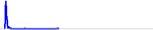

2005

101

73

1

459

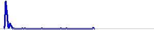

2006

109

73

1

746

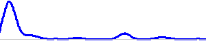

2007

389

132

1

746

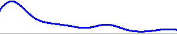

2008

851

380

1

746

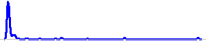

2009

290

151

1

746

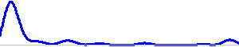

2010

88

66

1

746

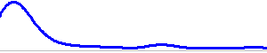

2011

65

46

1

746

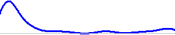

2012

79

53

1

746

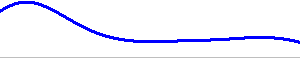

2013

75

54

1

746

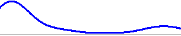

2014

73

44

1

746

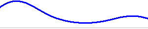

2015

70

41

1

746

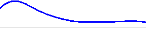

2016

79

41

1

746

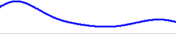

2017

105

52

1

746

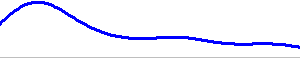

2018

93

62

1

746

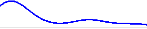

Summarize the non-human data, also by year.

```r
# Summarize Human case data by year
# Note: the output of this filters out potential Year/Source combos with only 1 subtype

campy_nonhuman %>%
  group_by(Year, Source) %>%
  summarize(n.isolates = n(),
            n.subtypes = length(unique(BCM95.v2)),
            min.size = min(BCM95.SA.size, na.rm = TRUE),
            max.size = max(BCM95.SA.size, na.rm = TRUE),
            subtype.size = list(BCM95.SA.size[!is.na(BCM95.SA.size)]),
            .groups = "keep") %>%
  mutate(Year = as.factor(Year)) %>%
  filter(n.subtypes >1) %>%
  flextable() %>%
  compose(j="subtype.size", value = as_paragraph(
    plot_chunk(value = subtype.size, type = "dens", col = "red")
  )) %>%
  set_caption("Summary of non-human C.jejuni isolates")
```

Summary of non-human C.jejuni isolates

Year

Source

n.isolates

n.subtypes

min.size

max.size

subtype.size

2001

Chicken

135

37

6

746

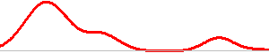

2002

Chicken

182

44

2

746

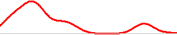

2003

Chicken

226

64

1

746

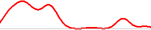

2004

Cattle

64

20

3

657

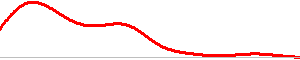

2004

Chicken

288

57

2

746

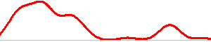

2004

Other

69

23

2

459

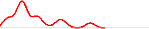

2004

Water

79

26

1

657

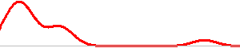

2005

Cattle

503

52

1

746

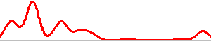

2005

Chicken

28

19

24

746

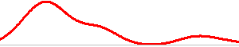

2005